# Moore_Nguyen_Data_Science_Project

### Food Access and Social Determinants of Health Affecting Obesity Rates

*Github link:* https://nmoore26.github.io/index.html

**The Team:** Nina Moore, Amy Le Nguyen

## **Project Goals**

Our project seeks to better understand which socioeconomic factors in the USA during 2015 most accurately affect the Obesity percentage rates in each of the States. Obesity is a wide-ranging issue in the United States and there are many unseen factors that contribute to the obesity rates in the USA. To assist us in this study, we have chosen three datasets.

Dataset 1 is:

- *[National Obesity Percentages by State (Data.gov):](https://catalog.data.gov/dataset/national-obesity-by-state-d765a)* Lists percentages of state population considered obese from a 2015 CDC survey. This serves as the basis for our data analysis.

This dataset is key to our analysis as it provides the obesity percentages in each state in 2015.

Dataset 2 is:

- *[Social Determinants of Health Database (Agency for Healthcare Research and Quality):](https://www.ahrq.gov/sdoh/data-analytics/sdoh-data.html)* A dataset with measures of 330 social determinants of health across all 50 states, with specificity by county, in 2015. We plan to look at race, median household income, percentage of households that have food stamps, etc.

This dataset is key as it introduces socioeconomic factors that will help us to determine if race is a key factor in the obesity rates seen in each state.

Dataset 3 is:

- *[Food Environmental Atlas (USDA):](https://www.ers.usda.gov/data-products/food-environment-atlas/data-access-and-documentation-downloads)* Measures access to food statewide for all 50 states. It considers variables like grocery stores, dollar stores, fast food restaurants, sit-down restaurants in the county.

This dataset is key as it provides data about the access to stores and therefore helps us to determine if the access to nutritious food is a factor in the obesity rates seen in each state.

Through the cleaning and analysis of these three datasets, we seek to answer the following questions:

1. How do access to grocery stores and restaurants contribute to obesity metrics?
2. Do median household income or statewide percentage of households with food stamps correlate with obesity?
3. Are certain populations more or less affected by obesity?
4. Which race has the highest rate of obesity?
5. Which race with the lowest access to food has the higher obesity %?
6. Which counties in a particular state are similar to each other and does a state's mean household income affect the obesity rates?
7. Are the Median Household Income, Percent Household Foodstamps, and the Adult Diabetes % key determining factors of obesity?

**Collaboration Plan:** We plan to meet every week at least once. For now, we'll meet every Thursday at 5:30 PM and will meet more as needed.

```python
# run program to access files from google drive
from google.colab import drive
drive.mount('/content/drive')
```

```python
# import necessary libraries
import pandas as pd
import numpy as np
import matplotlib.pyplot as plt
import seaborn as sns
from sklearn.preprocessing import StandardScaler

# change directory
%cd /content/drive/MyDrive/Colab Notebooks/Data Science Project
```

```
/content/drive/.shortcut-targets-by-id/19SLwXNlnKpDKEsV_STONH05KTXdZbLoS/Data Science Project
```

## **Dataset 1:**

The first data set to be loaded in focuses on the National Obesity Percentages by State.

```python
# load in 'National Obesity Percentages by State' dataset
obesity_percents_df = pd.read_csv('obesity_perc.csv',skiprows=1)
obesity_percents_df.head()
```

|  | OBJECTID | NAME | Obesity | Shape__Area | Shape__Length |
| --- | --- | --- | --- | --- | --- |
| 0 | 1 | Texas | 32.4 | 7.672329e+12 | 1.540832e+07 |
| 1 | 2 | California | 24.2 | 5.327809e+12 | 1.451870e+07 |
| 2 | 3 | Kentucky | 34.6 | 1.128830e+12 | 6.346699e+06 |
| 3 | 4 | Georgia | 30.7 | 1.652980e+12 | 5.795596e+06 |
| 4 | 5 | Wisconsin | 30.7 | 1.567816e+12 | 6.806782e+06 |

We only need access to the Name and Obesity columns and therefore the Shape_Area and Shape_Length columns were dropped. The new dataframe with the last two columns dropped is called **obesity_perc**. Since we are only considereing the 50 States, Puerto Rico was dropped.

```python
# a list of the column names we want in the cleaned data frame
columns_s = ["NAME","Obesity"]
# creates an original dataframe based off off the obesity_percents_df dataframe with only the specified columns. Makes sure that modifications don't affect original df
obesity_perc = obesity_percents_df[columns_s].copy()
delete = ['Puerto Rico']
#deletes Puerto Rico from the cleaned dataframe
obesity_perc = obesity_perc[~obesity_perc['NAME'].isin(delete)]
```

We want to discover which states have the highest and lowest percentages of obesity. We will perform the **max()** and **min()** operations on the Obesity column respectively to report those findings.

```python
#Displays the row with the state with the maximum obesity percentage
max_o = obesity_perc.loc[obesity_perc["Obesity"].idxmax()]
max_o
```

|  | 8 |
| --- | --- |
| NAME | Louisiana |
| Obesity | 36.2 |

**dtype:** object

```python
#Displays the row with the state with the minimum obesity percentage
min_o = obesity_perc.loc[obesity_perc["Obesity"].idxmin()]
min_o
```

|  | 25 |
| --- | --- |
| NAME | Colorado |
| Obesity | 20.2 |

**dtype:** object

The above operations tell us that Louisiana has the highest obesity at 36.2% and Colorado has the lowest obesity percentage at 20.2 %

We also want to discover the national average obesity percentage in 2015, the year this data was collected.

```python
# Displays the national average obesity rate in 2015
avg_o = obesity_perc["Obesity"].mean()
print(avg_o)
```

```
29.28235294117647
```

Below is a chart that displays the obesity rates per state including where those states are in respect to the national average obesity rate.

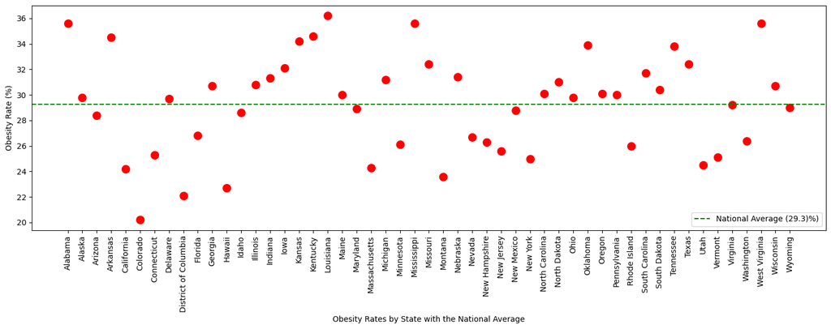

```python
#sorts the state names so that they are in order
sort_ob = obesity_perc.sort_values(by="NAME").reset_index(drop=True)
plt.figure(figsize=(15,6))
plt.scatter(sort_ob["NAME"],sort_ob["Obesity"],color='red',s=100)
#creates the line for the national average rate of obesity
plt.axhline(avg_o,color='green',linestyle='--',label=f'National Average ({avg_o:.1f})%)')
plt.xticks(rotation=90)
plt.ylabel("Obesity Rate (%)")
plt.xlabel("Obesity Rates by State with the National Average")
plt.legend()
plt.tight_layout()
```

## **Dataset 2:**

The Social Determinants of Health Database is 85530 x 330. Instead of loading in such a large database every time, we'll load in the variables of interest:

- State
- Percent American Indian and Native American
- Percent Asian
- Percent Black
- Percent Native Hawaiian and Pacific Islander
- Percent White
- Percent Unemployed
- Median Household Income
- Percent of Households with Food Stamps
- Percent of Households with Food Stamps Below the Poverty Line

The original dataset also included U.S. territories, which were dropped, as we are only considering the 50 states.

```python
# load in 'Social Determinants of Health Database'
# only consider columns with variables of interest
sdoh_df = pd.read_csv('SDOH_2015.csv', usecols=['STATE', 'COUNTY', 'ACS_PCT_AIAN_COMB',
                       'ACS_PCT_ASIAN_COMB', 'ACS_PCT_BLACK_COMB',
                       'ACS_PCT_NHPI_COMB', 'ACS_PCT_WHITE_COMB',
                       'ACS_PCT_UNEMPLOY', 'ACS_MEDIAN_HH_INC',
                       'ACS_PCT_HH_FOOD_STMP', 'ACS_PCT_HH_FOOD_STMP_BLW_POV']
                        )
# drop US territories
territories = ['Puerto Rico', 'Guam', 'American Samoa',
               'Northern Mariana Islands', 'US Virgin Islands']
sdoh_df = sdoh_df[~sdoh_df['STATE'].isin(territories)]

sdoh_df.head()
```

|  | STATE | COUNTY | ACS_PCT_AIAN_COMB | ACS_PCT_ASIAN_COMB | ACS_PCT_BLACK_COMB | ACS_PCT_NHPI_COMB | ACS_PCT_WHITE_COMB | ACS_PCT_UNEMPLOY | ACS_MEDIAN_HH_INC | ACS_PCT_HH_FOOD_STMP | ACS_PCT_HH_FOOD_STMP_BLW_POV |
| --- | --- | --- | --- | --- | --- | --- | --- | --- | --- | --- | --- |
| 0 | Alabama | Autauga County | 1.49 | 1.28 | 8.06 | 0.87 | 91.38 | 5.42 | 61838.0 | 15.21 | 6.60 |
| 1 | Alabama | Autauga County | 0.51 | 4.78 | 53.48 | 0.00 | 44.25 | 13.35 | 32303.0 | 30.59 | 17.56 |
| 2 | Alabama | Autauga County | 2.06 | 1.92 | 18.56 | 2.93 | 79.28 | 6.22 | 44922.0 | 11.98 | 4.51 |
| 3 | Alabama | Autauga County | 2.31 | 0.00 | 4.61 | 0.00 | 83.88 | 10.81 | 54329.0 | 2.47 | 0.49 |
| 4 | Alabama | Autauga County | 0.00 | 4.57 | 26.23 | 0.29 | 70.58 | 4.20 | 51965.0 | 13.73 | 5.48 |

We want to look at food stamp usage across each state. Since the original database separates information by county, which we will ignore, we need to group each variable of interest by state and consider only the percent of households with food stamps. We'll take the average in order to take the average percentage of food stamp usage across all the counties and find which states have the highest and lowest percentage of households with foodstamps.

```python
# group dataset by state and consider food stamps usage
# find the mean to get the state average (average across all counties)
avg_food_stamps = sdoh_df.groupby('STATE')['ACS_PCT_HH_FOOD_STMP'].mean()

# find state with the highest percentage
print('State with Highest Percentage of Households with Foodstamps:',
      avg_food_stamps.idxmax(), ',', round(avg_food_stamps.max(), 2), '%')
# find state with the lowest percentage
print('State with Lowest Percentage of Households with Foodstamps:',
      avg_food_stamps.idxmin(), ',', round(avg_food_stamps.min(), 2), '%')

# get a look at the first few states
avg_food_stamps.head()
```

```
State with Highest Percentage of Households with Foodstamps: Mississippi , 20.1 %
State with Lowest Percentage of Households with Foodstamps: Wyoming , 6.04 %
```

| STATE | ACS_PCT_HH_FOOD_STMP |
| --- | --- |
| Alabama | 18.318511 |
| Alaska | 11.940723 |
| Arizona | 14.596766 |
| Arkansas | 16.250920 |
| California | 9.959721 |

**dtype:** float64

The same process is repeated: taking the average across all the counties to find the median household income for each state. We'll locate where and find the highest and lowest median households incomes in America.

```python
# group social determinants of health dataset by state
# only consider the median household income variable and find the mean
avg_income = sdoh_df.groupby('STATE')['ACS_MEDIAN_HH_INC'].mean()

# find state with highest median household income
print('State with Highest Median Household Income:', avg_income.idxmax(),
      ', $', round(avg_income.max(), 2))
# find state with lowest median household income
print('State with Lowest Median Household Income:', avg_income.idxmin(),
      ', $', round(avg_income.min(), 2))

# get a look at the first few states
avg_income.head()
```

```
State with Highest Median Household Income: Maryland , $ 79136.84
State with Lowest Median Household Income: Mississippi , $ 38909.92
```

| STATE | ACS_MEDIAN_HH_INC |
| --- | --- |
| Alabama | 43296.358603 |
| Alaska | 70354.743902 |
| Arizona | 54207.820955 |
| Arkansas | 41935.633968 |
| California | 67333.661390 |

**dtype:** float64

To get a feel for how median household income might correlate with food access, which has implications on obesity, we'll plot our median household income data against our percentage of households with food stamps. Does median income in the state correlate with how prevalent food stamps are? Later, we'll see if this matches up with obesity and food stamps metrics.

```
Correlation between Median Household Income ($) vs. Food Stamps Prevalence: -0.531
```

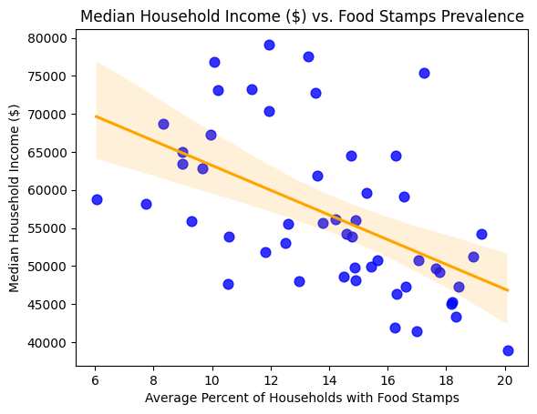

```python
# find correlation value between percentage of households with food stamps
# and median household income
corr_value = avg_food_stamps.corr(avg_income)
print(f"Correlation between Median Household Income ($) vs. Food Stamps Prevalence: {corr_value:.3f}")

# plot percentage of households with food stamps against median household income
sns.regplot(
    x=avg_food_stamps,
    y=avg_income,
    scatter_kws={"color": "blue", "s": 60},
    line_kws={"color": "orange"}
)
plt.xlabel('Average Percent of Households with Food Stamps')
plt.ylabel('Median Household Income ($)')
plt.title('Median Household Income ($) vs. Food Stamps Prevalence')
plt.show()
```

Just looking at the graph, there seems to be a negative correlation between median household income and percentage of households with food stamps. That is, as median household income increases, the average percent of households with foodstamps decreases. In reality, this means that states with lower median household incomes often have higher percentages of households on food stamps. Soon, we will explore how obesity correlates with both of these variables, but this exploratory analysis gives insight on how wealth affects food access.

## **Dataset 3:**

The Food Environmental Atlas dataset has over 300 variables, many of which are for years other than 2015, which is our year of interest. We will only consider the variables of interest for 2015:

- State
- County
- Low access to store, 2015
- Low access to store and low-income, 2015
- Households, no car & low access to store, 2015
- SNAP households, low access to store, 2015
- White, low access to store, 2015
- Black, low access to store, 2015
- Hispanic, low access to store, 2015
- Asian, low access to store, 2015
- American Indian or Alaska Native, low access to store, 2015
- Hawaiian or Pacific Islander, low access to store, 2015
- Multiracial, low access to store, 2015
- Food distribution centers on Native American reservations, 2015
- Adult diabetes rate, 2015

The 'State' column will be mapped so that each imported dataset is using the full state names, rather than the abbreviations, so that it is consistent with the rest of the datasets. Additionally, there are some negative diabetes rates in the 'Adult diabetes rate, 2015' data (presumably because there was no or missing data), so any rows with negative values will be dropped.

```python
# low-access populations
access_df = pd.read_csv('atlas_access.csv',
                       usecols=['State', 'County', 'LACCESS_POP15',
                       'LACCESS_LOWI15', 'LACCESS_HHNV15',
                       'LACCESS_SNAP15', 'LACCESS_WHITE15',
                       'LACCESS_BLACK15', 'LACCESS_HISP15',
                       'LACCESS_ASIAN15', 'LACCESS_AIAN15',
                       'LACCESS_HOPI15', 'LACCESS_MULTIR15'])

# food distribution centers on indian reservations
assistance_df = pd.read_csv('atlas_assistance.csv', usecols=['State', 'County',
                                                             'FDPIR15'])

# adult diabetes rates
diabetes_df = pd.read_csv('atlas_health.csv', usecols=['State', 'County',
                                                       'PCT_DIABETES_ADULTS15'])

# dictionary mapping abbreviations → full names
state_abbrev_to_name = {
    'AL': 'Alabama', 'AK': 'Alaska', 'AZ': 'Arizona', 'AR': 'Arkansas', 'CA': 'California',
    'CO': 'Colorado', 'CT': 'Connecticut', 'DE': 'Delaware', 'FL': 'Florida', 'GA': 'Georgia',
    'HI': 'Hawaii', 'ID': 'Idaho', 'IL': 'Illinois', 'IN': 'Indiana', 'IA': 'Iowa',
    'KS': 'Kansas', 'KY': 'Kentucky', 'LA': 'Louisiana', 'ME': 'Maine', 'MD': 'Maryland',
    'MA': 'Massachusetts', 'MI': 'Michigan', 'MN': 'Minnesota', 'MS': 'Mississippi',
    'MO': 'Missouri', 'MT': 'Montana', 'NE': 'Nebraska', 'NV': 'Nevada', 'NH': 'New Hampshire',
    'NJ': 'New Jersey', 'NM': 'New Mexico', 'NY': 'New York', 'NC': 'North Carolina',
    'ND': 'North Dakota', 'OH': 'Ohio', 'OK': 'Oklahoma', 'OR': 'Oregon', 'PA': 'Pennsylvania',
    'RI': 'Rhode Island', 'SC': 'South Carolina', 'SD': 'South Dakota', 'TN': 'Tennessee',
    'TX': 'Texas', 'UT': 'Utah', 'VT': 'Vermont', 'VA': 'Virginia', 'WA': 'Washington',
    'WV': 'West Virginia', 'WI': 'Wisconsin', 'WY': 'Wyoming', 'DC': 'District of Columbia'
}

# replace abbreviations with full names
access_df['State'] = access_df['State'].map(state_abbrev_to_name)
assistance_df['State'] = assistance_df['State'].map(state_abbrev_to_name)
diabetes_df['State'] = diabetes_df['State'].map(state_abbrev_to_name)

# drop diabetes rates that are negative
diabetes_df = diabetes_df[diabetes_df['PCT_DIABETES_ADULTS15'] >= 0]

display(access_df.head())
display(assistance_df.head())
display(diabetes_df.head())
```

|  | State | County | LACCESS_POP15 | LACCESS_LOWI15 | LACCESS_HHNV15 | LACCESS_SNAP15 | LACCESS_WHITE15 | LACCESS_BLACK15 | LACCESS_HISP15 | LACCESS_ASIAN15 | LACCESS_AIAN15 | LACCESS_HOPI15 | LACCESS_MULTIR15 |
| --- | --- | --- | --- | --- | --- | --- | --- | --- | --- | --- | --- | --- | --- |
| 0 | Alabama | Autauga | 18092.661350 | 6835.642497 | 677.672769 | 1822.537716 | 28592.192360 | 6645.162299 | 790.187847 | 188.457143 | 161.635647 | 15.711041 | 866.714452 |
| 1 | Alabama | Baldwin | 46400.350640 | 15459.848420 | 1394.162766 | 4874.837779 | 114569.054500 | 10709.565460 | 5400.587834 | 792.906323 | 971.615628 | 51.305996 | 4554.710751 |
| 2 | Alabama | Barbour | 6683.975691 | 3251.362574 | 425.144927 | 1357.606370 | 9924.136304 | 8196.688099 | 1055.536003 | 65.276832 | 101.195583 | 13.961786 | 896.003741 |
| 3 | Alabama | Bibb | 295.614426 | 164.903295 | 224.388125 | 972.185555 | 14775.827540 | 3775.872254 | 304.346057 | 16.574243 | 50.485583 | 3.915621 | 295.702565 |
| 4 | Alabama | Blount | 5855.939161 | 2570.900481 | 719.931444 | 2685.697327 | 48763.477090 | 552.119031 | 3827.607930 | 84.023054 | 279.703754 | 36.186185 | 2526.713164 |

|  | State | County | FDPIR15 |
| --- | --- | --- | --- |
| 0 | Alabama | Autauga | 0 |
| 1 | Alabama | Baldwin | 0 |
| 2 | Alabama | Barbour | 0 |
| 3 | Alabama | Bibb | 0 |
| 4 | Alabama | Blount | 0 |

|  | State | County | PCT_DIABETES_ADULTS15 |
| --- | --- | --- | --- |
| 0 | Alabama | Autauga | 9.1 |
| 1 | Alabama | Baldwin | 8.6 |
| 2 | Alabama | Barbour | 12.7 |
| 3 | Alabama | Bibb | 9.9 |
| 4 | Alabama | Blount | 9.9 |

We'll take a look at how populations with low access to food are affected by obesity. In the Food Atlas dataset, 'LACCESS_POP15' records the number of individuals in each county of the US that are said to have low access to food. The raw population counts are not very helpful to us, as states with larger total populations will naturally have a higher low-access population. We need a fairer way to compare between states, so we'll create what we call `state_contribution`.

In order to properly assess states' rates of low access to food, we'll take the sum of the 'LACCESS_POP15' column to find the total low-access population across the United States. Then, we'll use each state's individual low-access population counts to see what percentage of low-access individuals live in each state. This is what the `state_contribution` variable is.

```python
# total low-access population across all counties
total_low_access = access_df['LACCESS_POP15'].sum()

# add up low-access population by state
state_low_access = access_df.groupby('State')['LACCESS_POP15'].sum()

# normalize each state's low-access population by total
# this gives a sense of to national contribution
state_contribution = state_low_access / total_low_access

# sort to see which states contribute most to low food access
state_contribution_sorted = state_contribution.sort_values(ascending=False)

# print states with highest and lowest state contributions to low access to food
display(state_contribution_sorted.head())
print('State with largest rate of population with low access to food: ',
      state_contribution_sorted.idxmax(), ', ',
       round(state_contribution_sorted.max() * 100, 2), '%')
print('State with smallest rate of population with low access to food: ',
      state_contribution_sorted.idxmin(), ', ',
      round(state_contribution_sorted.min() * 100, 2), '%')
```

| State | LACCESS_POP15 |
| --- | --- |
| Texas | 0.098308 |
| California | 0.072016 |
| Florida | 0.069765 |
| Georgia | 0.043111 |
| Ohio | 0.042176 |

**dtype:** float64

```
State with largest rate of population with low access to food:  Texas ,  9.83 %
State with smallest rate of population with low access to food:  District of Columbia ,  0.02 %
```

Using this method, we see that 9.83% of the United States's low-access to food population is located in Texas. In contrast, only 0.02% of the country's population with low access to food is located in Washington, D.C.

We still want to see how state contribution and obesity percentages correlate with each other, however. Since they are on different scales, however (the maximum for `state_contribution` is 9.83% vs. 36.2% for `obesity_perc`), so we will z-score standardize the data.

```python
# z-score state contribution
state_contribution_sc = (state_contribution - np.mean(state_contribution)) / np.std(state_contribution)
display(state_contribution_sc.head())

# sort obesity_perc by state name first so that the state contribution and
# obesity percentage data correspond with the same state
obesity_perc = obesity_perc.sort_values("NAME").reset_index(drop=True)

# calculate z-score
obesity_perc["Obesity_sc"] = ((obesity_perc["Obesity"] - np.mean(obesity_perc["Obesity"])) /
                              np.std(obesity_perc["Obesity"]))
display(obesity_perc.head())
```

| State | LACCESS_POP15 |
| --- | --- |
| Alabama | -0.150623 |
| Alaska | -0.855953 |
| Arizona | 0.239758 |
| Arkansas | -0.497861 |
| California | 2.741574 |

**dtype:** float64

|  | NAME | Obesity | Obesity_sc |
| --- | --- | --- | --- |
| 0 | Alabama | 35.6 | 1.648349 |
| 1 | Alaska | 29.8 | 0.135060 |
| 2 | Arizona | 28.4 | -0.230216 |
| 3 | Arkansas | 34.5 | 1.361346 |
| 4 | California | 24.2 | -1.326046 |

Now that they are on comparable scales, we can plot each state's low access to food population against its obesity percentages.

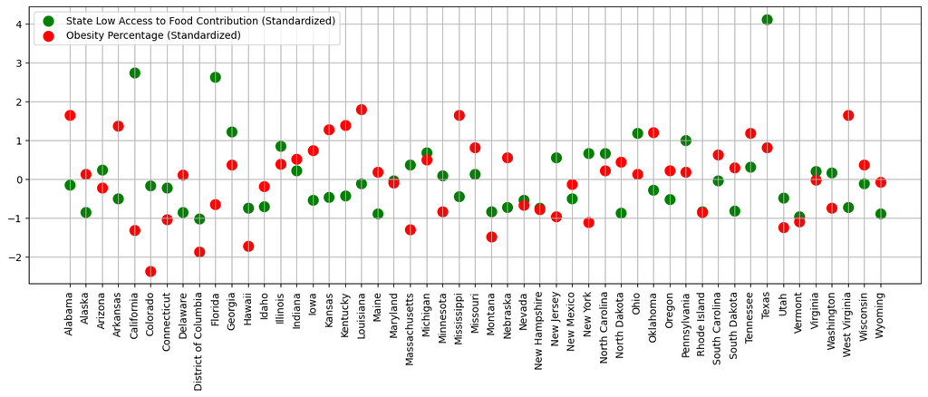

```python
# plot state contribution with low access for each state
plt.figure(figsize=(16,5))
plt.scatter(state_contribution.index, state_contribution_sc.values,
            color='green',s=100, label='State Low Access to Food Contribution (Standardized)')
plt.scatter(state_contribution.index, obesity_perc["Obesity_sc"], color='red',
            s=100, label='Obesity Percentage (Standardized)')
plt.xticks(rotation=90)
plt.grid(True)
plt.legend()
plt.show()
```

This visualization allows us to compare these variables on a state level, but it is difficult to gauge any real correlation between the variables. To do so, we'll simply plot the unstandardized points and find the correlation between the two using seaborn.

```
Correlation between low access to food and obesity: -0.439
```

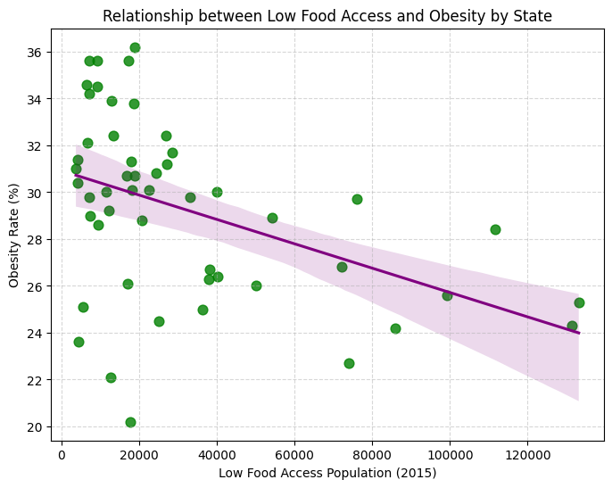

```python
# define low-access to food variable from access_df
low_access = access_df.groupby("State", as_index=False)["LACCESS_POP15"].mean()

# merge low_access with obesity_perc
merged = pd.merge(low_access, obesity_perc, left_on="State", right_on="NAME", how="inner")

# calculate correlation value between the two variables
corr_value = merged["LACCESS_POP15"].corr(merged["Obesity"])
print(f"Correlation between low access to food and obesity: {corr_value:.3f}")

# plot
plt.figure(figsize=(8,6))
sns.regplot(
    data=merged,
    x="LACCESS_POP15",
    y="Obesity",
    scatter_kws={"color": "green", "s": 60},
    line_kws={"color": "purple"}
)
plt.title("Relationship between Low Food Access and Obesity by State")
plt.xlabel("Low Food Access Population (2015)")
plt.ylabel("Obesity Rate (%)")
plt.grid(True, linestyle="--", alpha=0.5)
plt.show()
```

The correlation between low food access population and obesity rate is -0.439. This means that obesity rates go down within a state as the population with low food access goes up.

Finally, as a last step for preliminary exploratory analysis of data from the Food Atlas, we will find the correlation between diabetes and obesity rate using the `.corr()` function and visualizing it using seaborn's `sns.regplot()` function.

```
Correlation between diabetes rate and obesity rate: 0.569
```

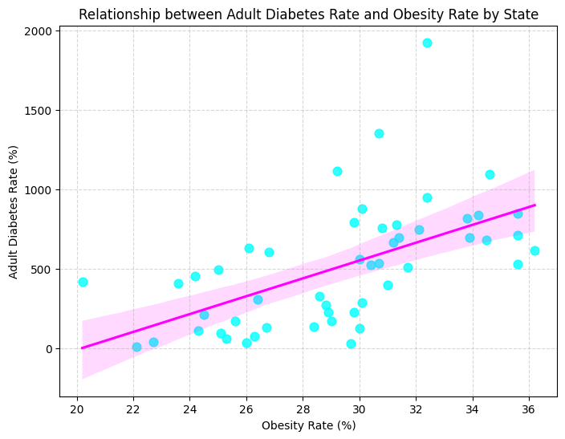

```python
# group diabetes data by state
diabetes_by_state = diabetes_df.groupby('State', as_index=False)['PCT_DIABETES_ADULTS15'].sum()

# calculate correlation
diabetes_obesity_corr = obesity_perc["Obesity"].corr(diabetes_by_state["PCT_DIABETES_ADULTS15"])
print(f"Correlation between diabetes rate and obesity rate: {diabetes_obesity_corr:.3f}")

# plot
plt.figure(figsize=(8,6))
sns.regplot(
    x= obesity_perc["Obesity"],
    y= diabetes_by_state['PCT_DIABETES_ADULTS15'],
    scatter_kws={"color": "cyan", "s": 60},
    line_kws={"color": "magenta"})
plt.title("Relationship between Adult Diabetes Rate and Obesity Rate by State")
plt.xlabel("Obesity Rate (%)")
plt.ylabel("Adult Diabetes Rate (%)")
plt.grid(True, linestyle="--", alpha=0.5)
plt.show()
```

The correlation between adult diabetes rate and obesity rate is 0.569, which means that diabetes rate increases with obesity rate with a moderate correlation. This serves as a reminder of why we are exploring social determinants of health on obesity: there are tangible health effects that come with obesity, which are often out of the individual's control.

## **Creating 2 New Dataframes**

Now that all 3 necessary datasets have been inputed and cleaned, certain features from each dataset will be concatenated into a single dataset to better understand which socioeconomic factors are highly correlated with obesity percentage. We want to create two dataframes that are related through the state column, one dataframe that doesn't have any variables related to race and another that has variables related to race. From these two dataframes, we will determine where race-based factors vs. non-race based factors are highly correlated with obesity percentages.

Now, we will create the first dataframe focusing on non-race based socioeconomic factors in the USA in 2015. To create this dataset, we will use the following columns from each of the datasets.

Dataset # 1

- `NAME`
- `Obesity`
- `Obesity_sc`

Dataset # 2

- `STATE`
- `COUNTY`
- `ACS_PCT_UNEMPLOY`
- `ACS_MEDIAN_HH_INC`
- `ACS_PCT_HH_FOOD_STMP`
- `ACS_PCT_HH_FOOD_STMP_BLW_POV`

Dataset # 3

- `State`
- `County`
- `LACCESS_POP15`
- `LACCESS_LOWI15`
- `LACCESS_HHNV15`
- `LACCESS_SNAP15`
- `LACCESS_WHITE15`
- `LACCESS_BLACK15`
- `LACCESS_HISP15`
- `LACCESS_ASIAN15`
- `LACCESS_AIAN15`
- `LACCESS_HOPI15`
- `LACCESS_MULTIR15`

from `access_df`

- `State`
- `County`
- `FDPIR15`

from the `assistance_df`

- `State`
- `County`
- `PCT_DIABETES_ADULTS15`

from the `diabetes_df`

For the last two datasets we will need to groupby states since these datasets contain the data for states by counties

- `ACS_PCT_ASIAN_COMB`
- `ACS_PCT_BLACK_COMB`
- `ACS_PCT_NHPI_COMB`
- `ACS_PCT_WHITE_COMB`

In the `first data` set we need to rename the state column of the dataset to be clearer.

```python
obesity_perc.rename(columns={'NAME': 'State'}, inplace=True)
obesity_perc.head(3)
```

|  | State | Obesity | Obesity_sc |
| --- | --- | --- | --- |
| 0 | Alabama | 35.6 | 1.648349 |
| 1 | Alaska | 29.8 | 0.135060 |
| 2 | Arizona | 28.4 | -0.230216 |

For the `second dataset` we need to first average all the column data values from each of the counties in a state so that we can look at the socioeconomic features from a state view.

```python
df_2 = sdoh_df.groupby('STATE',as_index=False).mean(numeric_only=True)
```

Then we will rename the columns so that they are easier to understand given the documentation on the dataset.

```python
df_2.rename(columns={'STATE': 'State', 'ACS_PCT_AIAN_COMB': 'Percent American Indian','ACS_PCT_ASIAN_COMB': 'Percent Asian',
                     'ACS_PCT_BLACK_COMB': 'Percent Black','ACS_PCT_NHPI_COMB': 'Percent Native Hawaian',
                     'ACS_PCT_WHITE_COMB': 'Percent White','ACS_PCT_UNEMPLOY': 'Percent Unemployed',
                     'ACS_MEDIAN_HH_INC': 'Median Household Income','ACS_PCT_HH_FOOD_STMP': 'Percent Household Foodstamps',
                     'ACS_PCT_HH_FOOD_STMP_BLW_POV': 'Percent Household Foodstamps (Below Poverty Line)'}, inplace=True)
```

We will separate the columns that aren't race related.

```python
df_2_no_race = df_2.drop(columns=[
    'Percent American Indian',
    'Percent Asian',
    'Percent Black',
    'Percent Native Hawaian',
    'Percent White'
])
```

For the `third dataset` we will do something similar. This includes dropping the columns from `access_df`, `assistance_df`, and `diabetes_df` that include race features,renaming the columns, and grouping data by state

```python
# get rid of any negative values that may affect the groupby function when averaging

# Replace negatives with NaN only in numeric columns
access_df[access_df.select_dtypes(include='number').columns] = \
    access_df.select_dtypes(include='number').apply(lambda x: x.where(x >= 0, np.nan))

assistance_df[assistance_df.select_dtypes(include='number').columns] = \
    assistance_df.select_dtypes(include='number').apply(lambda x: x.where(x >= 0, np.nan))

diabetes_df[diabetes_df.select_dtypes(include='number').columns] = \
    diabetes_df.select_dtypes(include='number').apply(lambda x: x.where(x >= 0, np.nan))

# Now group by State and take the mean (ignores NaN automatically)
access_3 = access_df.groupby('State', as_index=False).mean(numeric_only=True)
assistance_3 = assistance_df.groupby('State', as_index=False).mean(numeric_only=True)
diabetes_3 = diabetes_df.groupby('State', as_index=False).mean(numeric_only=True)
```

```python
one = access_3.rename(columns={'LACCESS_POP15':'Low Access to Store','LACCESS_LOWI15':'Low Income & Low Store Access','LACCESS_HHNV15':'No Car & Low Store Access',
                          'LACCESS_SNAP15':'SNAP & Low Store Access','LACCESS_WHITE15':'Low Store Access- Whites','LACCESS_BLACK15':'Low Store Access- Blacks',
                          'LACCESS_HISP15':'Low Store Access- Hispanics','LACCESS_ASIAN15':'Low Store Access- Asians','LACCESS_AIAN15':'Low Store Access- American Indian',
                          'LACCESS_HOPI15':'Low Store Access- Hawaian','LACCESS_MULTIR15':'Low Store Access- Multirace'})
one.head(2)
```

|  | State | Low Access to Store | Low Income & Low Store Access | No Car & Low Store Access | SNAP & Low Store Access | Low Store Access- Whites | Low Store Access- Blacks | Low Store Access- Hispanics | Low Store Access- Asians | Low Store Access- American Indian | Low Store Access- Hawaian | Low Store Access- Multirace |
| --- | --- | --- | --- | --- | --- | --- | --- | --- | --- | --- | --- | --- |
| 0 | Alabama | 17290.036637 | 6382.565391 | 868.654832 | 2524.026442 | 32720.167821 | 8964.194779 | 1412.931584 | 365.140414 | 306.952345 | 22.152596 | 1339.959882 |
| 1 | Alaska | 8362.622084 | 2312.975756 | 465.624533 | 480.047595 | 9627.427799 | 269.249645 | 586.739656 | 427.648519 | 2242.883510 | 58.855512 | 995.637697 |

```python
two = assistance_3.rename(columns={'FDPIR15':'Number of Food Asistance Sites'})
two.head(2)
```

|  | State | Number of Food Asistance Sites |
| --- | --- | --- |
| 0 | Alabama | 0.00000 |
| 1 | Alaska | 0.62069 |

```python
diabetes_3.columns
```

```
Index(['State', 'PCT_DIABETES_ADULTS15'], dtype='object')
```

```python
three = diabetes_3.rename(columns={'PCT_DIABETES_ADULTS15':'Adult Diabetes (%)'})
three.head(2)
```

|  | State | Adult Diabetes (%) |
| --- | --- | --- |
| 0 | Alabama | 10.607463 |
| 1 | Alaska | 7.779310 |

Now we will edit these dataset `one` to only contain non-race based features for our first dataframe.

```python
one.columns
```

```
Index(['State', 'Low Access to Store', 'Low Income & Low Store Access',
       'No Car & Low Store Access', 'SNAP & Low Store Access',
       'Low Store Access- Whites', 'Low Store Access- Blacks',
       'Low Store Access- Hispanics', 'Low Store Access- Asians',
       'Low Store Access- American Indian', 'Low Store Access- Hawaian',
       'Low Store Access- Multirace'],
      dtype='object')
```

```python
one_no_race = one.drop(columns=['Low Store Access- Whites', 'Low Store Access- Blacks',
       'Low Store Access- Hispanics', 'Low Store Access- Asians',
       'Low Store Access- American Indian',
       'Low Store Access- Hawaian', 'Low Store Access- Multirace'])
one_no_race.head(2)
```

|  | State | Low Access to Store | Low Income & Low Store Access | No Car & Low Store Access | SNAP & Low Store Access |
| --- | --- | --- | --- | --- | --- |
| 0 | Alabama | 17290.036637 | 6382.565391 | 868.654832 | 2524.026442 |
| 1 | Alaska | 8362.622084 | 2312.975756 | 465.624533 | 480.047595 |

Before we concatenate all the previous datasets into the non-race based dataframe, we need to check the formating of the state column in each dataset to see if joining on the 'State' column will introduce any errors.

```python
a = len(obesity_perc["State"].unique())
b = len(df_2_no_race["State"].unique())
c = len(one_no_race["State"].unique())
d = len(two["State"].unique())
e = len(three["State"].unique())


print(a,b,c,d,e)
```

```
51 51 51 51 51
```

Since they are the same length, we will now join on the state variable for all these datasets.

```python
merged_norace = obesity_perc.merge(df_2_no_race, on="State") \
                    .merge(one_no_race, on="State") \
                    .merge(two, on="State") \
                    .merge(three, on="State")
merged_norace.head(2)
```

|  | State | Obesity | Obesity_sc | Percent Unemployed | Median Household Income | Percent Household Foodstamps | Percent Household Foodstamps (Below Poverty Line) | Low Access to Store | Low Income & Low Store Access | No Car & Low Store Access | SNAP & Low Store Access | Number of Food Asistance Sites | Adult Diabetes (%) |
| --- | --- | --- | --- | --- | --- | --- | --- | --- | --- | --- | --- | --- | --- |
| 0 | Alabama | 35.6 | 1.648349 | 10.686877 | 43296.358603 | 18.318511 | 10.793677 | 17290.036637 | 6382.565391 | 868.654832 | 2524.026442 | 0.00000 | 10.607463 |
| 1 | Alaska | 29.8 | 0.135060 | 9.265843 | 70354.743902 | 11.940723 | 4.517048 | 8362.622084 | 2312.975756 | 465.624533 | 480.047595 | 0.62069 | 7.779310 |

Now we will create the second dataframe that uses race-based features.

```python
cols = list(set(df_2.columns) - set(df_2_no_race.columns))
keep = ['State'] + [col for col in cols if col != 'State']
df2_race = df_2[keep]
df2_race.head(2)
```

|  | State | Percent American Indian | Percent Black | Percent Asian | Percent Native Hawaian | Percent White |
| --- | --- | --- | --- | --- | --- | --- |
| 0 | Alabama | 1.192934 | 32.129235 | 1.356956 | 0.104940 | 65.577857 |
| 1 | Alaska | 22.424132 | 4.552754 | 7.184850 | 1.606826 | 71.495988 |

```python
cols_o = list(set(one.columns) - set(one_no_race.columns))
keep_o = ['State'] + [col for col in cols_o if col != 'State']
one_race = one[keep_o]
one_race.head(2)
```

|  | State | Low Store Access- Blacks | Low Store Access- Asians | Low Store Access- American Indian | Low Store Access- Hispanics | Low Store Access- Whites | Low Store Access- Multirace | Low Store Access- Hawaian |
| --- | --- | --- | --- | --- | --- | --- | --- | --- |
| 0 | Alabama | 8964.194779 | 365.140414 | 306.952345 | 1412.931584 | 32720.167821 | 1339.959882 | 22.152596 |
| 1 | Alaska | 269.249645 | 427.648519 | 2242.883510 | 586.739656 | 9627.427799 | 995.637697 | 58.855512 |

```python
merged_race = obesity_perc.merge(df2_race, on="State") \
                    .merge(one_race, on="State")
merged_race.head(2)
```

|  | State | Obesity | Obesity_sc | Percent American Indian | Percent Black | Percent Asian | Percent Native Hawaian | Percent White | Low Store Access- Blacks | Low Store Access- Asians | Low Store Access- American Indian | Low Store Access- Hispanics | Low Store Access- Whites | Low Store Access- Multirace | Low Store Access- Hawaian |
| --- | --- | --- | --- | --- | --- | --- | --- | --- | --- | --- | --- | --- | --- | --- | --- |
| 0 | Alabama | 35.6 | 1.648349 | 1.192934 | 32.129235 | 1.356956 | 0.104940 | 65.577857 | 8964.194779 | 365.140414 | 306.952345 | 1412.931584 | 32720.167821 | 1339.959882 | 22.152596 |
| 1 | Alaska | 29.8 | 0.135060 | 22.424132 | 4.552754 | 7.184850 | 1.606826 | 71.495988 | 269.249645 | 427.648519 | 2242.883510 | 586.739656 | 9627.427799 | 995.637697 | 58.855512 |

So now we have created two dataframes for our resulting analysis and model:

- `merged_norace`
- `merged_race`

Now we will employ a correlation matrix on both dataframes to determine which two models we could create that can predict obesity percentage more accurately. However first, we need to create a version of the dataframes without the `State` column, as a correlation matrix works only on numeric values.

```python
# merged_norace
corr_norace = merged_norace.drop(columns='State').corr()
# merged_race
corr_race = merged_race.drop(columns='State').corr()
```

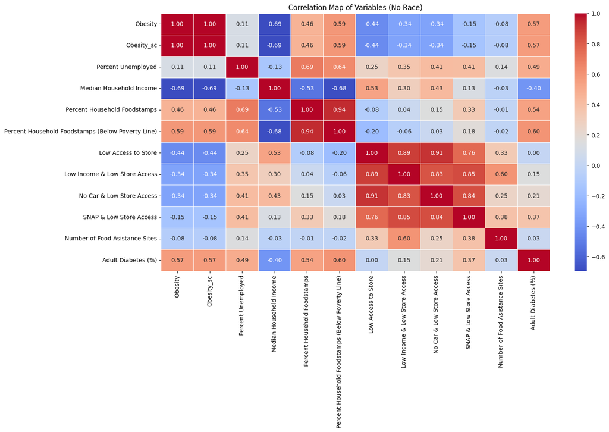

```python
# for no race
plt.figure(figsize=(15, 8))
sns.heatmap(corr_norace, annot=True, cmap='coolwarm', fmt=".2f", linewidths=.5)
plt.title('Correlation Map of Variables (No Race)')
plt.show()
```

From this correlation heat map, it can be seen that variables that deal with low store access are highly correlated with one another. This is expected, but this correlation matrix cements the idea that store access is a significant factor to consider. When considering factors that affect obesity specifically, 'Median Household Income' and 'Percent Household Foodstamps' seem to have moderate-high correlations.

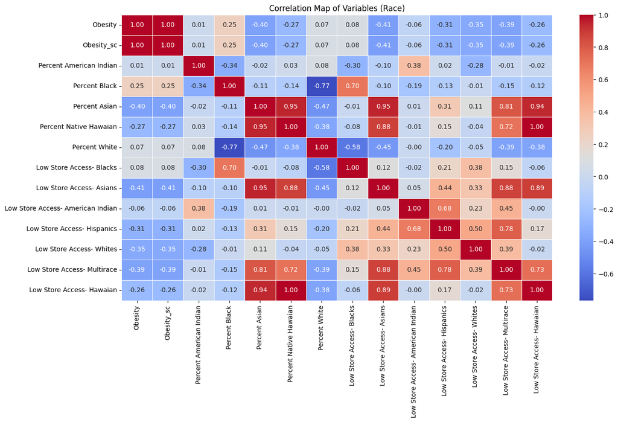

```python
# for race
plt.figure(figsize=(15, 8))
sns.heatmap(corr_race, annot=True, cmap='coolwarm', fmt=".2f", linewidths=.5)
plt.title('Correlation Map of Variables (Race)')
plt.show()
```

The correlation heat maps above show that race may not be a very significant factor in percentages of obesity in a state. This is shown by how there are fewer variables with a high correlation value in the merged dataframe focusing just on race-based scoioeconomic factors that the dataframe that focuses on non-race based socioeconomic factors.

## **Model Questions**

Given the above two correlation matrices, we are interested in creating 3 models in which the relationship between

- `Median Household Income` vs `Obesity %`
- `Percent Household Foodstamps` vs `Obesity %`

are examined. In these two models the **independant variables** are Median Household Income and Percent Household Foodstamps. The **dependant variable** in both models is **Obesity %**. We are additionally interested in modeling the relationship between

- `Adult Diabetes %` vs `Obesity %`.

Since we are dealing with numeric data a linear regression model is suitable for all 3 models. Our goal is to examine which of the three independant variables more accurately can predict Obesity %. These models shall be implemented at a later time.

```python
%%shell
jupyter nbconvert --to html "/content/drive/MyDrive/Colab Notebooks/Data Science Project/Moore_Nguyen_Data_Science_Project.ipynb"
```

```
[NbConvertApp] Converting notebook /content/drive/MyDrive/Colab Notebooks/Data Science Project/Moore_Nguyen_Data_Science_Project.ipynb to html
[NbConvertApp] Writing 389277 bytes to /content/drive/MyDrive/Colab Notebooks/Data Science Project/Moore_Nguyen_Data_Science_Project.html
```